# p8105_hw5_cb3262

Corey Brennan

November 9, 2017

# Problem 1

#### Number of entrances

NYC has a sprawling mass of subway tunnels and stations, which allows ample opportunity for data analysis. We examined the number of entrances at each subway station in the NYC area. From the data, we filtered subway stations that had over 10 entrances and visually plotted them. Perhaps not so surprisingly, 34th, 23rd, and 14th street had the highest amount of entrances.

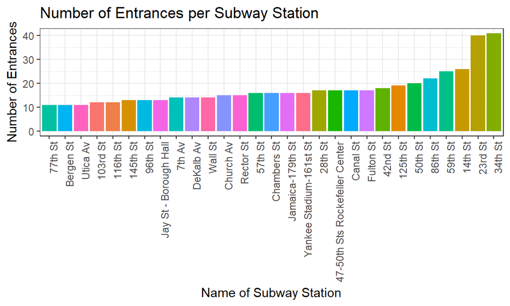

```r
#Importing nyc subway data from data.ny.gov and cleaning the data
nyc_subway = GET("https://data.ny.gov/resource/hvwh-qtfg.csv", query = list(`$limit` = 2000)) %>%
  content("parsed") %>%
  clean_names() %>%
  select(station_name, entrance_latitude, entrance_longitude, east_west_street, north_south_street, corner)
## Parsed with column specification:
## cols(
##   .default = col_character(),
##   ada = col_logical(),
##   entrance_latitude = col_double(),
##   entrance_longitude = col_double(),
##   free_crossover = col_logical(),
##   route10 = col_integer(),
##   route11 = col_integer(),
##   route8 = col_integer(),
##   route9 = col_integer(),
##   station_latitude = col_double(),
##   station_longitude = col_double()
## )
## See spec(...) for full column specifications.

nyc_subwayTen = nyc_subway %>%
  count(station_name) %>%
  filter(n > 10) %>%
  rename(count = n)

#Plotting number of entrances for stations with more than 10
ggplot(nyc_subwayTen, aes(x=reorder(station_name, count), y=count, fill=station_name)) +
    geom_bar(stat="identity") + guides(fill=FALSE) + theme(axis.text.x = element_text(angle = 90, hjust = 1)) + labs(
    title = "Number of Entrances per Subway Station",
    x = "Name of Subway Station",
    y = "Number of Entrances")
```

```r
#Counting stations with "St" in their name
nyc_subway_st = nyc_subway %>%
  filter(str_detect(station_name, "St")) %>%
  group_by(station_name) %>%
  summarise()


#Counting stations that end in "St"
nyc_subway_stEnd = nyc_subway %>%
  filter(str_detect(station_name, "St$")) %>%
  group_by(station_name) %>%
  summarise()
```

#### Subway stations with “St” in station name

We then examined the number of NYC subway stations that contained “St” in their name. 176 subway stations had “St” somewhere in their name, while 148 of those stations had “St” at the end of their name.

# Problem 2

#### Pulling and plotting data from the Game of Thrones page on Wikipedia

Game of Thrones has grown to be a massive hit, drawing in millions of viewers every episode. We decided to scrape some viewer data off of wikipedia to examine viewer amounts by season and episode. Initially, we cleaned and plotted the number of viewers per episode for each season:

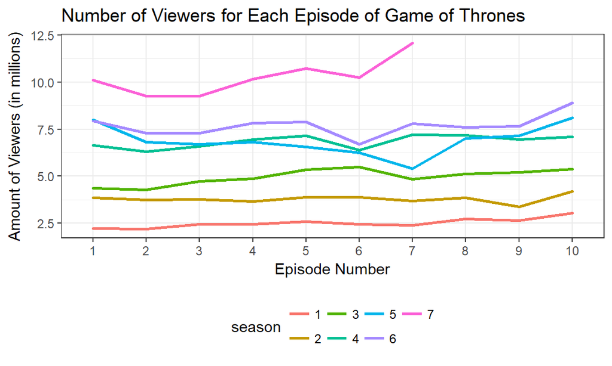

```r
#Reading in Game of Thrones viewer information from wikipedia
GoTView = read_html("https://en.wikipedia.org/wiki/Game_of_Thrones#Broadcast")
  GoTView = (GoTView %>% html_nodes(css = "table"))[[4]] %>%
  html_table() %>%
    clean_names() %>%
    as.tibble()

#Cleaning the Game of Thrones viewer data and preparing it for visualization
GoTView = (GoTView %>% select(-season)) %>%
  rename(season = season_2) %>%
  select(-average) %>%
  gather(key = episode, value = viewers, ep_1:ep_10) %>%
  mutate(epID = str_c(season, "S_E", str_sub(episode, 4, -1)), season = as.character(season)) %>%
  separate(episode, into = c("remove", "episode"), "_") %>%
  select(-remove) %>%
  mutate(episode = factor(episode, levels=c("1", "2", "3", "4", "5", "6", "7", "8", "9", "10")))

#Plotting the number of viewers per episode for each season
ggplot(GoTView, aes(x = episode, y = as.numeric(viewers), color=season)) + geom_point(size = 0.5) + geom_path(size = 1, aes(group = season)) + labs(
    title = "Number of Viewers for Each Episode of Game of Thrones",
    x = "Episode Number",
    y = "Amount of Viewers (in millions)")
## Warning in FUN(X[[i]], ...): NAs introduced by coercion
## Warning: Removed 3 rows containing missing values (geom_point).
## Warning: Removed 3 rows containing missing values (geom_path).
```

#### Box plot for each season

We then followed up our initial plot by creating a boxplot of the average viewers for each season:

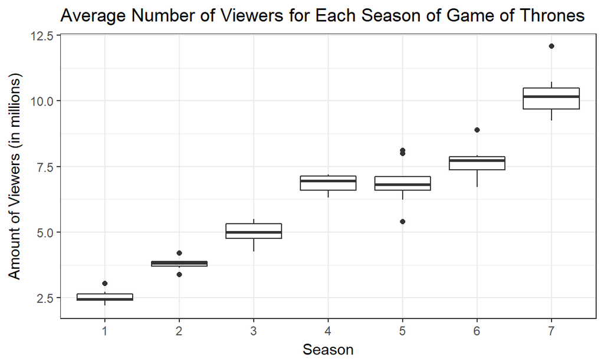

```r
#Plotting average viewers for each season
GoTView %>%
  group_by(season) %>%
  ggplot() + geom_boxplot(aes(x = season, y = as.numeric(viewers))) + labs(
    title = "Average Number of Viewers for Each Season of Game of Thrones",
    x = "Season",
    y = "Amount of Viewers (in millions)")
```

#### Linear regression model

Finally, we decided to create a linear regression model examining how season affects number of viewers. As we can see from the results below, there seems to be a noticeably increasing viewer trend as the season increases. All seasons below our reference, season 4, yield significantly lower viewers. Season 5 viewers are not significantly different, but both season 6 and season 7 have significantly higher viewer numbers than season 4 according to the model.

```r
#Preparing data for linear regression model
GoTView = GoTView %>%
  mutate(season = as.factor(season)) %>%
  mutate(season = relevel(season, ref = 4))

#Creating linear model
GoTModel = lm(as.numeric(viewers) ~ season, data = GoTView) %>%
  tidy() %>%
    select(term, estimate, p.value) %>%
    knitr::kable(digits = 3)
GoTModel
```

| term | estimate | p.value |
| --- | --- | --- |
| (Intercept) | 6.846 | 0.000 |
| season1 | -4.331 | 0.000 |
| season2 | -3.051 | 0.000 |
| season3 | -1.880 | 0.000 |
| season5 | 0.034 | 0.889 |
| season6 | 0.842 | 0.001 |
| season7 | 3.415 | 0.000 |

# Problem 3

```r
#Importing the Napoleon Dynamite reviews
dynRev = read_csv("../Data/dynamite_reviews.csv") %>%
  clean_names() %>%
  mutate(rowNum = row_number())
## Parsed with column specification:
## cols(
##   title = col_character(),
##   stars = col_integer(),
##   text = col_character()
## )

#Creating the dataset for the words of interest
data(stop_words)
dynWords = dynRev %>%
  unnest_tokens(word, text) %>%
  anti_join(stop_words)
## Joining, by = "word"
```

#### Scraping Napoleon Dynamite reviews from Amazon

In a questionable decision, we decided to scrape Amazon reviews from the storied classic Napoleon Dynamite. Looking at the dataset, three variables were extracted via scraping: title of the review, number of stars, and text of the review. From this, it appears that the scraping was successful in extracting the information that we would like in order to perform analyses.

#### Examining most used words for 5-star and 1-star reviews

We decided to examine the ten most frequent words used 5-star reviews, and then 1-star reviews. We can see that there are some warm words used in 5-star reviews such as “love” and “funny”:

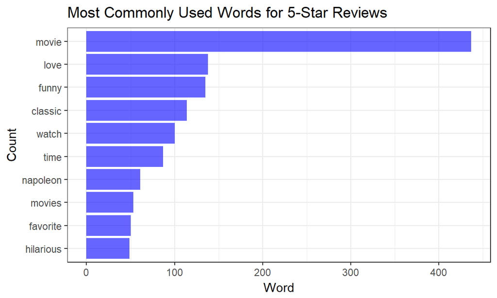

```r
#Examining most used words for 5-star reviews
dynWords %>%
  filter(stars == 5) %>%
  count(word, sort = TRUE) %>%
  top_n(10) %>%
  mutate(word = fct_reorder(word, n)) %>%
  ggplot(aes(x = word, y = n)) +
  geom_bar(stat = "identity", fill = "blue", alpha = .6) +
  coord_flip() + labs(
    title = "Most Commonly Used Words for 5-Star Reviews",
    x = "Count",
    y = "Word")
## Selecting by n
```

In contrast, 1-star reviews have negative words such as “dumb”, and presumably people complaining about disc format with words such as “dvd” and “blu”:

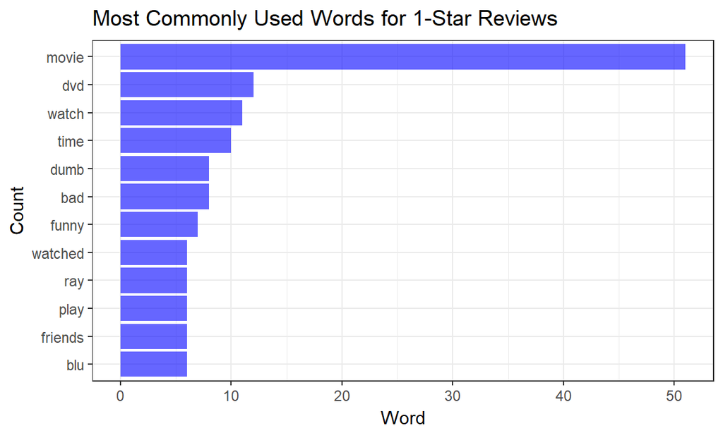

```r
#Examining most used words for 1-star reviews
dynWords %>%
  filter(stars == 1) %>%
  count(word, sort = TRUE) %>%
  top_n(10) %>%
  mutate(word = fct_reorder(word, n)) %>%
  ggplot(aes(x = word, y = n)) +
  geom_bar(stat = "identity", fill = "blue", alpha = .6) +
  coord_flip() + labs(
    title = "Most Commonly Used Words for 1-Star Reviews",
    x = "Count",
    y = "Word")
## Selecting by n
```

#### Log odds ratio of words in 1-star reviews versus 5-star reviews

To examine differences between words used in 1-star versus 5-star reviews, we decided to created a ratio of words used. We then took the log odds of this ratio and plotted it, unsurprisingly the 5-star reviews are positive while the 1-star reviews are negative:

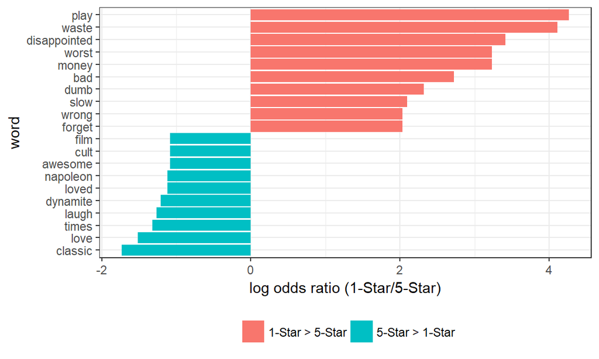

```r
#Creating word ratios for 1-star versus 5-star reviews
word_ratios = dynWords %>%
  filter(stars %in% c(1, 5)) %>%
  count(word, stars) %>%
  group_by(word) %>%
  filter(sum(n) >= 5) %>%
  ungroup() %>%
  spread(stars, n, fill = 0) %>%
  clean_names() %>%
  rename(oneStar = x1, fiveStar = x5) %>%
  mutate(
    oneStarOdds = (oneStar + 1) / (sum(oneStar) + 1),
    fiveStarOdds = (fiveStar + 1) / (sum(fiveStar) + 1),
    log_OR = log(oneStarOdds / fiveStarOdds)
  ) %>%
  arrange(desc(log_OR))

#Creating plot for logOdds
word_ratios %>%
  mutate(pos_log_OR = ifelse(log_OR > 0, "1-Star > 5-Star", "5-Star > 1-Star")) %>%
  group_by(pos_log_OR) %>%
  top_n(10, abs(log_OR)) %>%
  ungroup() %>%
  mutate(word = fct_reorder(word, log_OR)) %>%
  ggplot(aes(word, log_OR, fill = pos_log_OR)) +
  geom_col() +
  coord_flip() +
  ylab("log odds ratio (1-Star/5-Star)") +
  scale_fill_discrete(name = "")
```

#### Bing sentiment scale

To follow up the word ratio examination, we decided to examine the average sentiment in each review based on the bing sentiment rating system. Using this we plotted out the average sentiment of each review stratified by rating. As you can see below, the sentiment follows the trend you would expect, with 5-star reviews being more positive and 1-star reviews being largely negative:

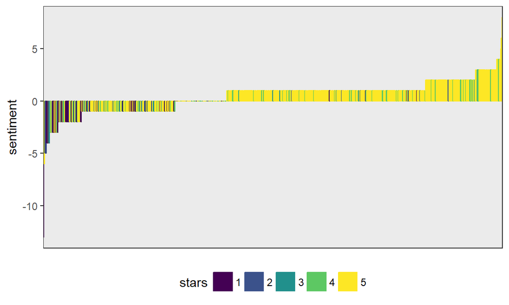

```r
#Creating bing sentiments for the Napoleon Dynamite Review
bing_sentiments = get_sentiments("bing")
dynSentiments = dynWords %>%
  inner_join(., bing_sentiments) %>%
  count(rowNum, sentiment) %>%
  spread(sentiment, n, fill = 0) %>%
  mutate(sentiment = positive - negative) %>%
  select(rowNum, sentiment) %>%
  left_join(dynRev,
             by = "rowNum")
## Joining, by = "word"

#Visually displaying sentiments for star reviews
dynSentiments %>%
  mutate(rowNum = factor(rowNum),
    rowNum = fct_reorder(rowNum, sentiment)) %>%
  mutate(stars = as.character(stars)) %>%
  ggplot(aes(x = rowNum,
             y = sentiment, fill = stars, color = stars)) +
  geom_bar(stat = "identity") +
  theme(axis.title.x = element_blank(),
        axis.text.x = element_blank(),
        axis.ticks.x = element_blank()) +
  scale_fill_viridis(discrete = TRUE) +
  scale_color_viridis(discrete = TRUE)
```

The most negative review had a sentiment score of -13, with the 1 star review stating “Let me start by openly admitting that I am an 80’s throwback and proud of it. I understand that my era did not produce horribly intelligent, deeply touching movies. That being said, this movie puts the Du-h! in Dumb!! My teenage daughter had seen it a sleepover, so we rented it so she could show me how silly it is for our girly night. She actually got tickled at a few spots on her second run through it. I sat open mouthed, amazed at the sheer senselessness of the whole thing…waiting desperately for a plot or growth of a character. None came. Since we had it rented for the weekend, she showed it to her older brother the next night. She giggled again, and he snickered with a confused look on his face once in a while. Then we couldn’t let my Hubby miss out on the sheer stupidity of it all, so we watched it with him on Sunday afternoon. Our daughter and son both snickered here and there, mostly at the looks on their parents’ faces. My husband was, as was I, gobsmackered. We kept looking at each other as if to assure each other that it was indeed that painfully dumb. The only real emotion I felt was a horribly heartbroken, sick to my stomach feeling for Napoleon and his friends for being so awkward and socially inept…I remember kids who struggled in school that way, and I always almost cried every time I saw them in a tough situation. If anything it brought back bad memories of school….who needs that? Anyway, all this to say it is a story about an awkward boy who uses bluster and dumb responses to deal with not fitting in. It follows (if you can exaggerate and say there is a plot) him as he finds friends (just as goofy as he) and finds romance…sort of.”